# Modeling AutoBi with tweedie Package

Seth Temple

```r
library(tweedie)
library(statmod)
library(ggplot2)
library(insuranceData)
```

```r
data(AutoBi)
```

Wrangle the AGE column.

```r
AgeFactor <- with(AutoBi, {
  (CLMAGE == "0" | CLMAGE == "1" | CLMAGE == "2" | CLMAGE == "3" | CLMAGE == "4" | CLMAGE == "5" | CLMAGE == "6" | CLMAGE == "7" | CLMAGE == "8" | CLMAGE == "9")*1 + (CLMAGE == "10" | CLMAGE == "11" | CLMAGE == "12" | CLMAGE == "13" | CLMAGE == "14" | CLMAGE == "15" | CLMAGE == "16" | CLMAGE == "17" | CLMAGE == "18" | CLMAGE == "19")*2 + (CLMAGE == "20" | CLMAGE == "21" | CLMAGE == "22" | CLMAGE == "23" | CLMAGE == "24" | CLMAGE == "25" | CLMAGE == "26" | CLMAGE == "27" | CLMAGE == "28" | CLMAGE == "29" | CLMAGE == "30" | CLMAGE == "31" | CLMAGE == "32" | CLMAGE == "33" | CLMAGE == "34" | CLMAGE == "35" | CLMAGE == "36" | CLMAGE == "37" | CLMAGE == "38" | CLMAGE == "39")*3 + (CLMAGE == "40" | CLMAGE == "41" | CLMAGE == "42" | CLMAGE == "43" | CLMAGE == "44" | CLMAGE == "45" | CLMAGE == "46" | CLMAGE == "47" | CLMAGE == "48" | CLMAGE == "49" | CLMAGE == "50" | CLMAGE == "51" | CLMAGE == "52" | CLMAGE == "53" | CLMAGE == "54" | CLMAGE == "55" | CLMAGE == "56" | CLMAGE == "57" | CLMAGE == "58" | CLMAGE == "59")*4 + (CLMAGE == "60" | CLMAGE == "61" | CLMAGE == "62" | CLMAGE == "63" | CLMAGE == "64" | CLMAGE == "65" | CLMAGE == "66" | CLMAGE == "67" | CLMAGE == "68" | CLMAGE == "69" |CLMAGE == "70" | CLMAGE == "71" | CLMAGE == "72" | CLMAGE == "73" | CLMAGE == "74" | CLMAGE == "75" | CLMAGE == "76" | CLMAGE == "77" | CLMAGE == "78" | CLMAGE == "79" | CLMAGE == "80" | CLMAGE == "81" | CLMAGE == "82" | CLMAGE == "83" | CLMAGE == "84" | CLMAGE == "85" | CLMAGE == "86" | CLMAGE == "87" | CLMAGE == "88" | CLMAGE == "89" | CLMAGE == "90" | CLMAGE == "91" | CLMAGE == "92" | CLMAGE == "93" | CLMAGE == "94" | CLMAGE == "95" | CLMAGE == "96" | CLMAGE == "97" | CLMAGE == "98" | CLMAGE == "99")*5
}
)
AutoBi$AGE <- AgeFactor
rm(AgeFactor)
```

Record empties as 0.

```r
AutoBi$CASENUM <- ifelse(is.na(AutoBi$CASENUM), 0, AutoBi$CASENUM)
AutoBi$MARITAL <- ifelse(is.na(AutoBi$MARITAL), 0, AutoBi$MARITAL)
AutoBi$AGE <- ifelse(is.na(AutoBi$AGE), 0, AutoBi$AGE)
AutoBi$ATTORNEY <- ifelse(is.na(AutoBi$ATTORNEY), 0, AutoBi$ATTORNEY)
AutoBi$CLMSEX <- ifelse(is.na(AutoBi$CLMSEX), 0, AutoBi$CLMSEX)
AutoBi$CLMAGE <- ifelse(is.na(AutoBi$CLMAGE), 0, AutoBi$CLMAGE)
AutoBi$CLMINSUR <- ifelse(is.na(AutoBi$CLMINSUR), 0, AutoBi$CLMINSUR)
AutoBi$SEATBELT <- ifelse(is.na(AutoBi$SEATBELT), 0, AutoBi$SEATBELT)
```

Build a model.

Model with no features.

```r
m0 <- glm(LOSS~1, data=AutoBi, family=tweedie(link.power=0, var.power=2))
summary(m0)
```

```
Call:
glm(formula = LOSS ~ 1, family = tweedie(link.power = 0, var.power = 2),
    data = AutoBi)

Deviance Residuals:
    Min       1Q   Median       3Q      Max
-3.4880  -1.6357  -0.8114  -0.3741  18.6092

Coefficients:
            Estimate Std. Error t value Pr(>|t|)
(Intercept)    1.784      0.152   11.73   <2e-16 ***
---
Signif. codes:  0 ‘***’ 0.001 ‘**’ 0.01 ‘*’ 0.05 ‘.’ 0.1 ‘ ’ 1

(Dispersion parameter for Tweedie family taken to be 30.97893)

    Null deviance: 3289  on 1339  degrees of freedom
Residual deviance: 3289  on 1339  degrees of freedom
AIC: NA

Number of Fisher Scoring iterations: 7
```

Model with one feature.

```r
m1 <- glm(LOSS~1+as.factor(ATTORNEY),
          data=AutoBi,
          family=tweedie(link.power=0, var.power=2))
summary(m1)
```

```
Call:
glm(formula = LOSS ~ 1 + as.factor(ATTORNEY), family = tweedie(link.power = 0,
    var.power = 2), data = AutoBi)

Deviance Residuals:
    Min       1Q   Median       3Q      Max
-3.1382  -1.2625  -0.8387  -0.0535  14.3225

Coefficients:
                     Estimate Std. Error t value Pr(>|t|)
(Intercept)            2.2888     0.1387  16.497   <2e-16 ***
as.factor(ATTORNEY)2  -1.6657     0.1984  -8.394   <2e-16 ***
---
Signif. codes:  0 ‘***’ 0.001 ‘**’ 0.01 ‘*’ 0.05 ‘.’ 0.1 ‘ ’ 1

(Dispersion parameter for Tweedie family taken to be 13.18627)

    Null deviance: 3289.0  on 1339  degrees of freedom
Residual deviance: 2459.9  on 1338  degrees of freedom
AIC: NA

Number of Fisher Scoring iterations: 7
```

```r
anova(m1,m0)
```

```
Analysis of Deviance Table

Model 1: LOSS ~ 1 + as.factor(ATTORNEY)
Model 2: LOSS ~ 1
  Resid. Df Resid. Dev Df Deviance
1      1338     2459.9
2      1339     3289.0 -1   -829.1
```

```r
print("AIC change")
```

```
[1] "AIC change"
```

```r
print(AICtweedie(m1) - AICtweedie(m0))
```

```
[1] -497.1678
```

We like ATTORNEY as a feature. It decreases the deviance, and it is significant for a reasonable confidence level.

Add another feature to the model.

```r
m2 <- glm(LOSS~1+as.factor(ATTORNEY)+as.factor(AGE),
          data=AutoBi,
          family=tweedie(link.power=0, var.power=2))
summary(m2)
```

```
Call:
glm(formula = LOSS ~ 1 + as.factor(ATTORNEY) + as.factor(AGE),
    family = tweedie(link.power = 0, var.power = 2), data = AutoBi)

Deviance Residuals:
    Min       1Q   Median       3Q      Max
-3.1501  -1.2368  -0.7311  -0.0299  11.4118

Coefficients:
                     Estimate Std. Error t value Pr(>|t|)
(Intercept)            2.7195     0.2138  12.718  < 2e-16 ***
as.factor(ATTORNEY)2  -1.5810     0.1476 -10.715  < 2e-16 ***
as.factor(AGE)1       -1.8145     0.3578  -5.072  4.5e-07 ***
as.factor(AGE)2       -0.9826     0.2685  -3.660 0.000262 ***
as.factor(AGE)3       -0.4780     0.2319  -2.061 0.039482 *
as.factor(AGE)4       -0.2784     0.2500  -1.113 0.265771
as.factor(AGE)5       -0.9261     0.3586  -2.582 0.009915 **
---
Signif. codes:  0 ‘***’ 0.001 ‘**’ 0.01 ‘*’ 0.05 ‘.’ 0.1 ‘ ’ 1

(Dispersion parameter for Tweedie family taken to be 7.222971)

    Null deviance: 3289.0  on 1339  degrees of freedom
Residual deviance: 2241.1  on 1333  degrees of freedom
AIC: NA

Number of Fisher Scoring iterations: 10
```

```r
anova(m2,m1)
```

```
Analysis of Deviance Table

Model 1: LOSS ~ 1 + as.factor(ATTORNEY) + as.factor(AGE)
Model 2: LOSS ~ 1 + as.factor(ATTORNEY)
  Resid. Df Resid. Dev Df Deviance
1      1333     2241.1
2      1338     2459.9 -5  -218.75
```

```r
print("AIC change")
```

```
[1] "AIC change"
```

```r
print(AICtweedie(m2) - AICtweedie(m1))
```

```
[1] -145.3754
```

We like AGE as a feature. It decreases the deviance, and it is significant for a reasonable confidence level.

Add another feature.

```r
m3 <- glm(LOSS~1+as.factor(ATTORNEY)+as.factor(AGE)+as.factor(SEATBELT),
          data=AutoBi,
          family=tweedie(link.power=0, var.power=2))
summary(m3)
```

```
Call:
glm(formula = LOSS ~ 1 + as.factor(ATTORNEY) + as.factor(AGE) +
    as.factor(SEATBELT), family = tweedie(link.power = 0, var.power = 2),
    data = AutoBi)

Deviance Residuals:
    Min       1Q   Median       3Q      Max
-3.1460  -1.2192  -0.7082  -0.0240  11.4635

Coefficients:
                     Estimate Std. Error t value Pr(>|t|)
(Intercept)            1.9808     0.4261   4.649 3.67e-06 ***
as.factor(ATTORNEY)2  -1.5479     0.1468 -10.543  < 2e-16 ***
as.factor(AGE)1       -1.8112     0.3555  -5.095 3.99e-07 ***
as.factor(AGE)2       -0.9800     0.2670  -3.670 0.000252 ***
as.factor(AGE)3       -0.5154     0.2306  -2.235 0.025603 *
as.factor(AGE)4       -0.2795     0.2487  -1.124 0.261272
as.factor(AGE)5       -0.9211     0.3567  -2.583 0.009915 **
as.factor(SEATBELT)1   0.7302     0.3936   1.855 0.063766 .
as.factor(SEATBELT)2   1.6254     0.6896   2.357 0.018569 *
---
Signif. codes:  0 ‘***’ 0.001 ‘**’ 0.01 ‘*’ 0.05 ‘.’ 0.1 ‘ ’ 1

(Dispersion parameter for Tweedie family taken to be 7.127291)

    Null deviance: 3289.0  on 1339  degrees of freedom
Residual deviance: 2197.3  on 1331  degrees of freedom
AIC: NA

Number of Fisher Scoring iterations: 10
```

```r
anova(m3,m2)
```

```
Analysis of Deviance Table

Model 1: LOSS ~ 1 + as.factor(ATTORNEY) + as.factor(AGE) + as.factor(SEATBELT)
Model 2: LOSS ~ 1 + as.factor(ATTORNEY) + as.factor(AGE)
  Resid. Df Resid. Dev Df Deviance
1      1331     2197.3
2      1333     2241.1 -2   -43.77
```

```r
print("AIC change")
```

```
[1] "AIC change"
```

```r
print(AICtweedie(m3) - AICtweedie(m2))
```

```
[1] -28.62965
```

We’ll keep SEATBELT in as a feature as well. It decreases the deviance a little. ATTORNEY is the explanatory variable that is the most significant. Observe that the change in AIC has been getting smaller.

Try to add one last feature.

```r
m4 <- glm(LOSS~1+as.factor(ATTORNEY)+as.factor(AGE)+as.factor(SEATBELT)
          +as.factor(CLMINSUR),
          data=AutoBi,
          family=tweedie(link.power=0, var.power=2))
summary(m4)
```

```
Call:
glm(formula = LOSS ~ 1 + as.factor(ATTORNEY) + as.factor(AGE) +
    as.factor(SEATBELT) + as.factor(CLMINSUR), family = tweedie(link.power = 0,
    var.power = 2), data = AutoBi)

Deviance Residuals:
    Min       1Q   Median       3Q      Max
-3.1559  -1.2149  -0.7069  -0.0325  11.3611

Coefficients:
                      Estimate Std. Error t value Pr(>|t|)
(Intercept)           1.981604   0.472012   4.198 2.87e-05 ***
as.factor(ATTORNEY)2 -1.549072   0.145219 -10.667  < 2e-16 ***
as.factor(AGE)1      -1.823693   0.351084  -5.194 2.37e-07 ***
as.factor(AGE)2      -0.975901   0.263354  -3.706  0.00022 ***
as.factor(AGE)3      -0.499704   0.227926  -2.192  0.02852 *
as.factor(AGE)4      -0.269711   0.245582  -1.098  0.27229
as.factor(AGE)5      -0.924191   0.351856  -2.627  0.00872 **
as.factor(SEATBELT)1  0.749631   0.482367   1.554  0.12041
as.factor(SEATBELT)2  1.616690   0.740820   2.182  0.02926 *
as.factor(CLMINSUR)1 -0.291352   0.567036  -0.514  0.60747
as.factor(CLMINSUR)2 -0.003354   0.522019  -0.006  0.99487
---
Signif. codes:  0 ‘***’ 0.001 ‘**’ 0.01 ‘*’ 0.05 ‘.’ 0.1 ‘ ’ 1

(Dispersion parameter for Tweedie family taken to be 6.924109)

    Null deviance: 3289.0  on 1339  degrees of freedom
Residual deviance: 2189.1  on 1329  degrees of freedom
AIC: NA

Number of Fisher Scoring iterations: 10
```

```r
anova(m4,m3)
```

```
Analysis of Deviance Table

Model 1: LOSS ~ 1 + as.factor(ATTORNEY) + as.factor(AGE) + as.factor(SEATBELT) +
    as.factor(CLMINSUR)
Model 2: LOSS ~ 1 + as.factor(ATTORNEY) + as.factor(AGE) + as.factor(SEATBELT)
  Resid. Df Resid. Dev Df Deviance
1      1329     2189.1
2      1331     2197.3 -2  -8.2718
```

```r
print("AIC change")
```

```
[1] "AIC change"
```

```r
print(AICtweedie(m4) - AICtweedie(m3))
```

```
[1] -2.228699
```

We’ll keep CLMINSUR in as a feature in the model. It decreases deviance and our penalized measure of fit by a little. Exercise care though, because we don’t get significance for this explanatory variable. We don’t want to say anything too scientific or matter-of-fact about how a claimant having insurance affects the loss cost.

Record that the dispersion parameter for this Tweedie model is 6.924109. We will see how the dispersion parameter changes when we find p in a more intelligent manner. For our current model, we arbitrarily chose p to be 2. This choice corresponds to the losses being distributed as gamma random variables.

Dunn and Smyth developed the tweedie.profile function. This algorithm does MLE estimation to find the power/index parameter p. Moreover, p influences the dispersion parameter. The algorithm estimates the dispersion parameter as well.

Use tweedie.profile function to estimate p and phi (the dispersion parameter.

```
---
 This function may take some time to complete;
 Please be patient.  If it fails, try using  method="series"
 rather than the default  method="inversion"
 Another possible reason for failure is the range of p:
 Try a different input for  p.vec
---
2 2.1 2.2 2.3 2.4 2.5 2.6 2.7 2.8 2.9 3
p = 2
* Fitting initial model: Done
* Phi estimation, method:  mle (using optimize):  Done (phi = 1.941025 )
* Computing the log-likelihood (method = interpolation ): Done: L = -3469.226
p = 2.1
* Fitting initial model: Done
* Phi estimation, method:  mle (using optimize):  Done (phi = 1.788113 )
* Computing the log-likelihood (method = interpolation ): Done: L = -3392.899
p = 2.2
* Fitting initial model: Done
* Phi estimation, method:  mle (using optimize):  Done (phi = 1.664594 )
* Computing the log-likelihood (method = interpolation ): Done: L = -3335.065
p = 2.3
* Fitting initial model: Done
* Phi estimation, method:  mle (using optimize):  Done (phi = 1.570862 )
* Computing the log-likelihood (method = interpolation ): Done: L = -3293.987
p = 2.4
* Fitting initial model: Done
* Phi estimation, method:  mle (using optimize):  Done (phi = 1.507034 )
* Computing the log-likelihood (method = interpolation ): Done: L = -3268.873
p = 2.5
* Fitting initial model: Done
* Phi estimation, method:  mle (using optimize):  Done (phi = 1.473818 )
* Computing the log-likelihood (method = interpolation ): Done: L = -3259.549
p = 2.6
* Fitting initial model: Done
* Phi estimation, method:  mle (using optimize):  Done (phi = 1.473377 )
* Computing the log-likelihood (method = interpolation ): Done: L = -3266.256
p = 2.7
* Fitting initial model: Done
* Phi estimation, method:  mle (using optimize):  Done (phi = 1.509872 )
* Computing the log-likelihood (method = interpolation ): Done: L = -3289.492
p = 2.8
* Fitting initial model: Done
* Phi estimation, method:  mle (using optimize):  Done (phi = 1.59061 )
* Computing the log-likelihood (method = interpolation ): Done: L = -3329.867
p = 2.9
* Fitting initial model: Done
* Phi estimation, method:  mle (using optimize):  Done (phi = 1.727494 )
* Computing the log-likelihood (method = interpolation ): Done: L = -3387.955
p = 3
* Fitting initial model: Done
* Phi estimation, method:  mle (using optimize):  Done (phi = 1.93904 )
* Computing the log-likelihood (method = interpolation ): Done: L = -3464.106
 Some values of L are infinite or NA, and hence ignored
 Done
 Finding maximum likelihood estimates:   Done
ML Estimates:   p = 2.5  with phi= 1.473818  giving L= -3259.549
 ---
```

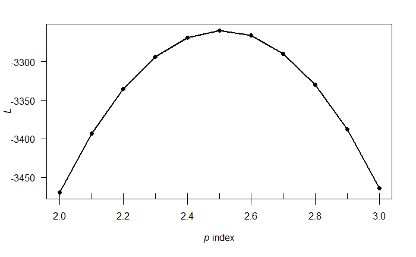

```r
start <- Sys.time()
# identity link
output <- tweedie.profile(LOSS~1, data=AutoBi, link.power=1,
                          method="interpolation", verbose=2,
                          do.plot=TRUE, do.smooth=FALSE,
                          p.vec=seq(2,3,.1))
```

```r
end <- Sys.time()
print(end-start)
```

```
Time difference of 6.044223 secs
```

The code executed in 6 seconds. MLE gives p=2.5 and phi=1.473818. Given parameters, the interpolation method decides how to find the density. See papers by Dunn and Smyth on series evaluation and Fourier inversion.

Notably, phi (the dispersion parameter) got smaller with our MLE estimate for p.

Compare interpolation with series method.

```
---
 This function may take some time to complete;
 Please be patient.  If it fails, try using  method="series"
 rather than the default  method="inversion"
 Another possible reason for failure is the range of p:
 Try a different input for  p.vec
---
2 2.1 2.2 2.3 2.4 2.5 2.6 2.7 2.8 2.9 3
p = 2
* Fitting initial model: Done
* Phi estimation, method:  mle (using optimize):  Done (phi = 1.941025 )
* Computing the log-likelihood (method = series ): Done: L = -3469.226
p = 2.1
* Fitting initial model: Done
* Phi estimation, method:  mle (using optimize):  Done (phi = 1.788113 )
* Computing the log-likelihood (method = series ): Done: L = -3392.899
p = 2.2
* Fitting initial model: Done
* Phi estimation, method:  mle (using optimize):  Done (phi = 1.664594 )
* Computing the log-likelihood (method = series ): Done: L = -3335.065
p = 2.3
* Fitting initial model: Done
* Phi estimation, method:  mle (using optimize):  Done (phi = 1.570862 )
* Computing the log-likelihood (method = series ): Done: L = -3293.987
p = 2.4
* Fitting initial model: Done
* Phi estimation, method:  mle (using optimize):  Done (phi = 1.507034 )
* Computing the log-likelihood (method = series ): Done: L = -3268.873
p = 2.5
* Fitting initial model: Done
* Phi estimation, method:  mle (using optimize):  Done (phi = 1.473818 )
* Computing the log-likelihood (method = series ): Done: L = -3259.55
p = 2.6
* Fitting initial model: Done
* Phi estimation, method:  mle (using optimize):  Done (phi = 1.473377 )
* Computing the log-likelihood (method = series ): Done: L = -3268.801
p = 2.7
* Fitting initial model: Done
* Phi estimation, method:  mle (using optimize):  Done (phi = 1.509872 )
* Computing the log-likelihood (method = series ): Done: L = -Inf
p = 2.8
* Fitting initial model: Done
* Phi estimation, method:  mle (using optimize):  Done (phi = 1.59061 )
* Computing the log-likelihood (method = series ): Done: L = -3275.976
p = 2.9
* Fitting initial model: Done
* Phi estimation, method:  mle (using optimize):  Done (phi = 1.727494 )
* Computing the log-likelihood (method = series ): Done: L = -Inf
p = 3
* Fitting initial model: Done
* Phi estimation, method:  mle (using optimize):  Done (phi = 1.93904 )
* Computing the log-likelihood (method = series ): Done: L = -Inf
 Some values of L are infinite or NA, and hence ignored
 Done
 Finding maximum likelihood estimates:   Done
ML Estimates:   p = 2.5  with phi= 1.473818  giving L= -3259.55
 ---
```

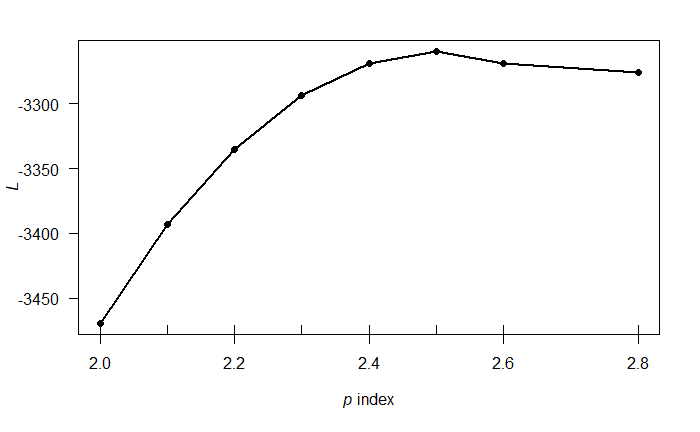

```r
start <- Sys.time()
# identity link
series_output <- tweedie.profile(LOSS~1, data=AutoBi, link.power=1,
                          method="series", verbose=2,
                          do.plot=TRUE, do.smooth=FALSE,
                          p.vec=seq(2,3,.1))
```

```r
end <- Sys.time()
print(end-start)
```

```
Time difference of 6.365943 secs
```

Time to execute code is roughly the same. But series evaluation fails for the p closer to 3. MLE estimates remain the same.

```
---
 This function may take some time to complete;
 Please be patient.  If it fails, try using  method="series"
 rather than the default  method="inversion"
 Another possible reason for failure is the range of p:
 Try a different input for  p.vec
---
2 2.1 2.2 2.3 2.4 2.5 2.6 2.7 2.8 2.9 3
p = 2
* Fitting initial model: Done
* Phi estimation, method:  mle (using optimize):  Done (phi = 1.941025 )
* Computing the log-likelihood (method = inversion ): Done: L = -3469.226
p = 2.1
* Fitting initial model: Done
* Phi estimation, method:  mle (using optimize):  Done (phi = 1.788113 )
* Computing the log-likelihood (method = inversion ): Done: L = -3392.899
p = 2.2
* Fitting initial model: Done
* Phi estimation, method:  mle (using optimize):  Done (phi = 1.664594 )
* Computing the log-likelihood (method = inversion ): Done: L = -3335.065
p = 2.3
* Fitting initial model: Done
* Phi estimation, method:  mle (using optimize):  Done (phi = 1.570862 )
* Computing the log-likelihood (method = inversion ): Done: L = -3293.987
p = 2.4
* Fitting initial model: Done
* Phi estimation, method:  mle (using optimize):  Done (phi = 1.507034 )
* Computing the log-likelihood (method = inversion ): Done: L = -3268.873
p = 2.5
* Fitting initial model: Done
* Phi estimation, method:  mle (using optimize):  Done (phi = 1.473818 )
* Computing the log-likelihood (method = inversion ): Done: L = -3259.549
p = 2.6
* Fitting initial model: Done
* Phi estimation, method:  mle (using optimize):  Done (phi = 1.473377 )
* Computing the log-likelihood (method = inversion ): Done: L = -3266.256
p = 2.7
* Fitting initial model: Done
* Phi estimation, method:  mle (using optimize):  Done (phi = 1.509872 )
* Computing the log-likelihood (method = inversion ): Done: L = -3289.492
p = 2.8
* Fitting initial model: Done
* Phi estimation, method:  mle (using optimize):  Done (phi = 1.59061 )
* Computing the log-likelihood (method = inversion ): Done: L = -3329.867
p = 2.9
* Fitting initial model: Done
* Phi estimation, method:  mle (using optimize):  Done (phi = 1.727494 )
* Computing the log-likelihood (method = inversion ): Done: L = -3387.955
p = 3
* Fitting initial model: Done
* Phi estimation, method:  mle (using optimize):  Done (phi = 1.93904 )
* Computing the log-likelihood (method = inversion ): Done: L = -3464.106
 Some values of L are infinite or NA, and hence ignored
 Done
 Finding maximum likelihood estimates:   Done
ML Estimates:   p = 2.5  with phi= 1.473818  giving L= -3259.549
 ---
```

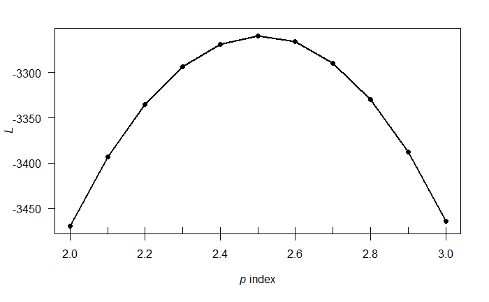

```r
start <- Sys.time()
# identity link
inversion_output <- tweedie.profile(LOSS~1, data=AutoBi, link.power=1,
                          method="inversion", verbose=2,
                          do.plot=TRUE, do.smooth=FALSE,
                          p.vec=seq(2,3,.1))
```

```r
end <- Sys.time()
print(end-start)
```

```
Time difference of 39.85687 secs
```

Inversion method takes longer to exectute. We get log likelihoods for all tested power/index parameter values.

Let’s change some other parameters in the tweedie.profile function.

Test more power parameter values.

```
2 2.02 2.04 2.06 2.08 2.1 2.12 2.14 2.16 2.18 2.2 2.22 2.24 2.26 2.28 2.3 2.32 2.34 2.36 2.38 2.4 2.42 2.44 2.46 2.48 2.5 2.52 2.54 2.56 2.58 2.6 2.62 2.64 2.66 2.68 2.7 2.72 2.74 2.76 2.78 2.8 2.82 2.84 2.86 2.88 2.9 2.92 2.94 2.96 2.98 3
...................................................Done.
```

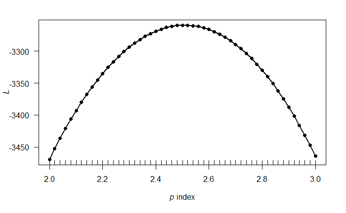

```r
start <- Sys.time()
# identity link
output <- tweedie.profile(LOSS~1, data=AutoBi, link.power=1,
                                    method="interpolation",
                                    do.plot=TRUE, do.smooth=FALSE,
                                    p.vec=seq(2,3,.02))
```

```r
end <- Sys.time()
print(end-start)
```

```
Time difference of 27.05721 secs
```

```r
print(output$p.max)
```

```
[1] 2.5
```

```r
print(output$phi.max)
```

```
[1] 1.473838
```

MLE estimates for p and phi did not change. We didn’t need to use so many possible power parameter values. We only wrote code that ran slower.

Change the window that we test power parameter values in.

```
2 2.1 2.2 2.3 2.4 2.5 2.6 2.7 2.8 2.9 3 3.1 3.2 3.3 3.4 3.5 3.6 3.7 3.8 3.9 4
.....................Done.
```

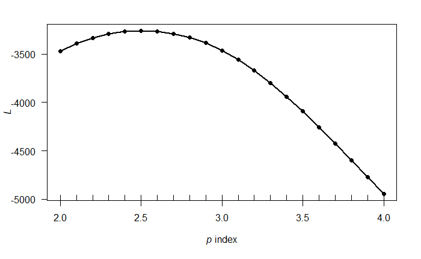

```r
start <- Sys.time()
# identity link
output <- tweedie.profile(LOSS~1, data=AutoBi, link.power=1,
                                    method="interpolation",
                                    do.plot=TRUE, do.smooth=FALSE,
                                    p.vec=seq(2,4,.1))
```

```r
end <- Sys.time()
print(end-start)
```

```
Time difference of 35.13563 secs
```

```r
print(output$p.max)
```

```
[1] 2.5
```

```r
print(output$phi.max)
```

```
[1] 1.473818
```

MLE gives the same p and phi.

We don’t extend the left bound further because the vector must have exact zeros for us to consider the data Poisson-gamma distributed. The code runs into issues if we do this.

```
2 2.2 2.4 2.6 2.8 3 3.2 3.4 3.6 3.8 4 4.2 4.4 4.6 4.8 5
................Done.
```

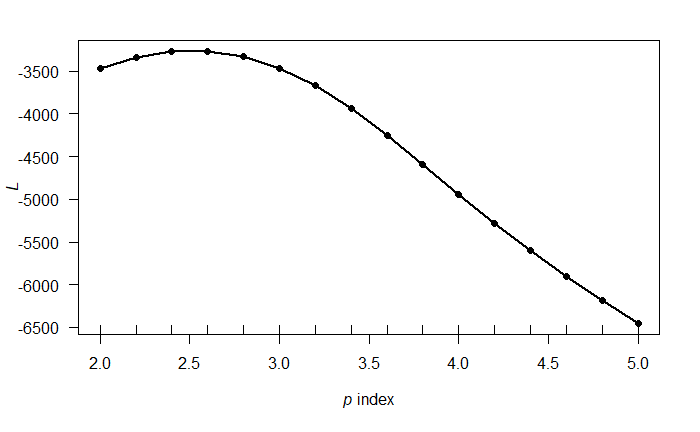

```r
start <- Sys.time()
# identity link
output <- tweedie.profile(LOSS~1, data=AutoBi, link.power=1,
                                    method="interpolation",
                                    do.plot=TRUE, do.smooth=FALSE,
                                    p.vec=seq(2,5,.2))
```

```r
end <- Sys.time()
print(end-start)
```

```
Time difference of 37.53027 secs
```

```r
print(output$p.max)
```

```
[1] 2.6
```

```r
print(output$phi.max)
```

```
[1] 1.473364
```

Here we see a change. Did extending the right bound or lengthening the interval spacing cause this change?

```
2 2.1 2.2 2.3 2.4 2.5 2.6 2.7 2.8 2.9 3 3.1 3.2 3.3 3.4 3.5 3.6 3.7 3.8 3.9 4 4.1 4.2 4.3 4.4 4.5 4.6 4.7 4.8 4.9 5 5.1 5.2 5.3 5.4 5.5 5.6 5.7 5.8 5.9 6
.........................................Done.
```

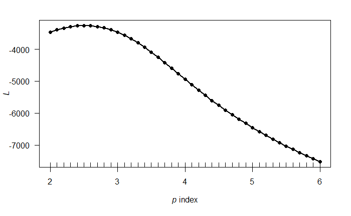

```r
start <- Sys.time()
# identity link
output <- tweedie.profile(LOSS~1, data=AutoBi, link.power=1,
                                    method="interpolation",
                                    do.plot=TRUE, do.smooth=FALSE,
                                    p.vec=seq(2,6,.1))
```

```r
end <- Sys.time()
print(end-start)
```

```
Time difference of 2.368818 mins
```

```r
print(output$p.max)
```

```
[1] 2.5
```

```r
print(output$phi.max)
```

```
[1] 1.473818
```

It looks like the change was caused by adjusting the interval spacing.

```
2 2.05 2.1 2.15 2.2 2.25 2.3 2.35 2.4 2.45 2.5 2.55 2.6 2.65 2.7 2.75 2.8 2.85 2.9 2.95 3
.....................Done.
```

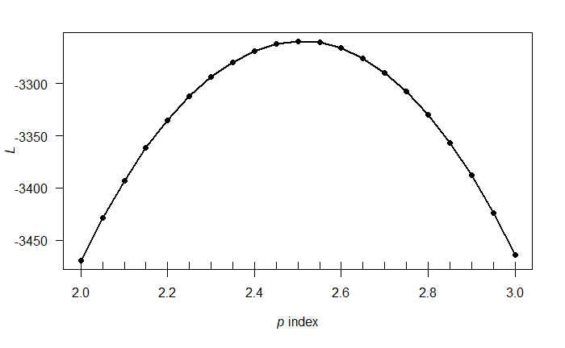

```r
start <- Sys.time()
# identity link
output <- tweedie.profile(LOSS~1, data=AutoBi, link.power=1,
                                    method="interpolation",
                                    do.plot=TRUE, do.smooth=FALSE,
                                    p.vec=seq(2,3,.05))
```

```r
end <- Sys.time()
print(end-start)
```

```
Time difference of 9.240445 secs
```

```r
print(output$p.max)
```

```
[1] 2.5
```

```r
print(output$phi.max)
```

```
[1] 1.473839
```

The interval spacing can affect MLE if we pick intervals too wide.

From this short analysis, we suspect AutoBi’s claim costs data is distributed like a Tweedie model with power 2.5.

Assess if the our model improves with this new choice of p.

Write some functions that give feedback.

```r
give_feedback <- function(model){
  SSR <- sum((model$residuals)**2)
  fitted_values <- model$fitted.values
  print("Squared Sum of Residuals"); print(SSR)
  print("Deviance"); print(model$deviance)
  print("AIC"); print(AICtweedie(model))
}
compare_insurance_models <- function(model1, model2){

  SSR1 <- sum((model1$residuals)**2)
  SSR2 <- sum((model2$residuals)**2)
  diff_SSR <- SSR1 - SSR2

  fitted_values1 <- model1$fitted.values
  fitted_values2 <- model2$fitted.values
  diff_fitted_values <- fitted_values1 - fitted_values2
  diff_losses <- sum(abs(diff_fitted_values))
  diff_econ = sum(model1$fitted.values - model2$fitted.values)

  diff_deviance <- model1$deviance - model2$deviance
  diff_AIC <- AICtweedie(model1) - AICtweedie(model2)

  print("Model differences are relative to the first model")
  print("Squared Sum of Residuals"); print(diff_SSR)
  print("Deviance"); print(diff_deviance)
  print("AIC"); print(diff_AIC)

  print("Sum of absolute differences between losses"); print(diff_losses)
  print("Total difference between losses"); print(diff_econ)

  print("First 10 differences in fitted losses")
  print(diff_fitted_values[1:5])

}
```

Intepret the results.

```r
arbitrary_p_model <- glm(LOSS~1+as.factor(SEATBELT)+as.factor(ATTORNEY)
                         +as.factor(AGE)+as.factor(CLMINSUR), data=AutoBi,
                         family=tweedie(link.power=0, var.power=2))
give_feedback(arbitrary_p_model)
```

```
[1] "Squared Sum of Residuals"
[1] 9202.141
[1] "Deviance"
[1] 2189.076
[1] "AIC"
[1] 6319.662
```

```r
intelligent_p_model <- glm(LOSS~1+as.factor(SEATBELT)+as.factor(ATTORNEY)
                         +as.factor(AGE)+as.factor(CLMINSUR), data=AutoBi,
                         family=tweedie(link.power=0, var.power=output$p.max))
give_feedback(intelligent_p_model)
```

```
[1] "Squared Sum of Residuals"
[1] 12102.1
[1] "Deviance"
[1] 1662.322
[1] "AIC"
[1] 6180.233
```

```r
compare_insurance_models(intelligent_p_model, arbitrary_p_model)
```

[output not shown]

Interestingly, the Tweedie model with 2.5 as its power has a larger squared sum of residuals, but smaller deviance and AIC. Numerically, it has larger residual errors relative to the specific dataset. On the other hand, it is the more likely model from what we know about statistics and probability theory.

How much change could this added sophistication provide?

```r
sum(intelligent_p_model$fitted.values)/sum(AutoBi$LOSS)
```

```
[1] 0.9213874
```

```r
sum(arbitrary_p_model$fitted.values)/sum(AutoBi$LOSS)
```

```
[1] 0.9567911
```

This change is at least noticeable. We would need to assess if the change provides any value to an insurance business though. To estimate the tweedie power parameter in this way, the actuary would need to use R. Changing software could be costly for an insurance company.

Conclude with some visualization.

```r
IntelligentModelResults <- data.frame(FittedValues=exp(predict(intelligent_p_model)),
                                      Values=AutoBi$LOSS,
                                      Residuals=intelligent_p_model$residuals,
                                      PreExpFittedValues=predict(intelligent_p_model),
                                      PreExpValues=log(AutoBi$LOSS),
                                      Age=as.factor(AutoBi$AGE),
                                      Attorney=as.factor(AutoBi$ATTORNEY),
                                      Seatbelt=as.factor(AutoBi$SEATBELT),
                                      Insured=as.factor(AutoBi$CLMINSUR),
                                      Case=as.factor(AutoBi$CASENUM))
```

```r
ArbitraryModelResults <- data.frame(FittedValues=exp(predict(arbitrary_p_model)),
                                      Values=AutoBi$LOSS,
                                      Residuals=arbitrary_p_model$residuals,
                                      PreExpFittedValues=predict(arbitrary_p_model),
                                      PreExpValues=log(AutoBi$LOSS),
                                      Age=as.factor(AutoBi$AGE),
                                      Attorney=as.factor(AutoBi$ATTORNEY),
                                      Seatbelt=as.factor(AutoBi$SEATBELT),
                                      Insured=as.factor(AutoBi$CLMINSUR),
                                      Case=as.factor(AutoBi$CASENUM))
```

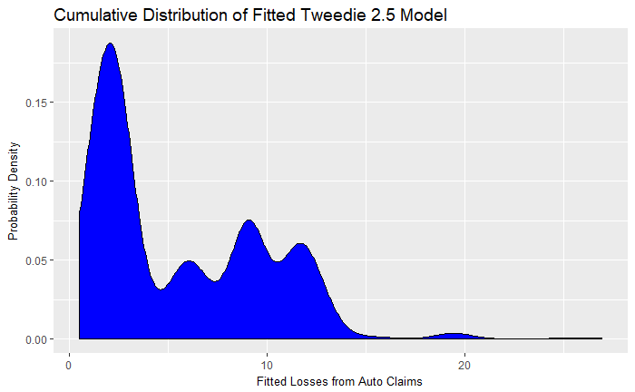

```r
p1 <- ggplot(data=IntelligentModelResults, aes(x=FittedValues))
p1 + geom_density(size=.5, colour="black", fill="blue") +
  ggtitle("Cumulative Distribution of Fitted Tweedie 2.5 Model") +
  ylab("Probability Density") +
  xlab("Fitted Losses from Auto Claims") +
  theme(axis.title.x=element_text(size=10, family="sans"),
        axis.title.y=element_text(size=10, family="sans"),
        plot.title=element_text(size=14, family="sans"))
```

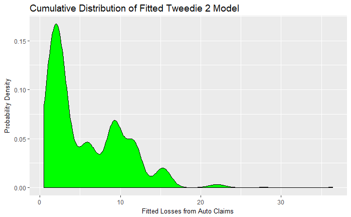

```r
p2 <- ggplot(data=ArbitraryModelResults, aes(x=FittedValues))
p2 + geom_density(size=.5, colour="black", fill="green") +
  ggtitle("Cumulative Distribution of Fitted Tweedie 2 Model") +
  ylab("Probability Density") +
  xlab("Fitted Losses from Auto Claims") +
  theme(axis.title.x=element_text(size=10, family="sans"),
        axis.title.y=element_text(size=10, family="sans"),
        plot.title=element_text(size=14, family="sans"))
```

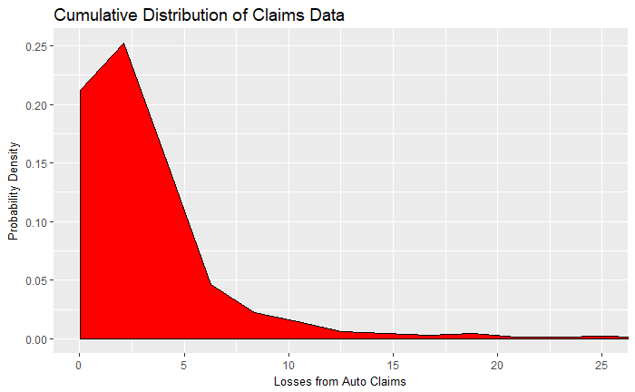

```r
p3 <- ggplot(data=IntelligentModelResults, aes(x=Values))
p3 + geom_density(size=.5, colour="black", fill="red") +
  coord_cartesian(xlim=c(0,25)) +
  ggtitle("Cumulative Distribution of Claims Data") +
  ylab("Probability Density") +
  xlab("Losses from Auto Claims") +
  theme(axis.title.x=element_text(size=10, family="sans"),
        axis.title.y=element_text(size=10, family="sans"),
        plot.title=element_text(size=14, family="sans"))
```

It is hard to draw any conclusions from the graphs. Both Tweedie models appear to do a decent job modeling the actual claims data. Also, they look very similar. This similarity matches with our earlier observation that losses only change marginally (by the cents or by a couple of dollars) for a given observation.

The upshot of this study: we can more accurately model claim costs by being more sophisticated in how we select the power parameter. This notebook looks into claims severity. Actuaries traditionally model claims severity with an inverse-Gaussian distribution or a gamma distribution.